# Bitcoin Price Forecasting

Keerthikant

##### Forecast is a generic function for forecasting from time series or time series models. The function invokes particular methods which depend on the class of the first argument.

##### Naniar package is used to plot heatmap to check missing values in the data

##### Lubridate package is used for to work with dates and times

```r
setwd('C:/Users/keert/Documents/Keerthi/Personal/ML/Time series/bitcoin/Code')
library(forecast)
library(ggplot2)
library(lubridate)
library(dplyr)
library(naniar)
library(tseries)
```

##### Let’s load the input file which is the training file provided in the bitcoin dataset.

```r
train_data=read.csv('C:/Users/keert/Documents/Keerthi/Personal/ML/Time series/bitcoin/Data/Bitcoin_Train_Data.csv',header=TRUE)
test_data=read.csv('C:/Users/keert/Documents/Keerthi/Personal/ML/Time series/bitcoin/Data/Bitcoin_Test_Data.csv',header=TRUE)
```

##### Initial checks to convert date field so that we can work on time series models.

```r
str(train_data)
```

```
## 'data.frame':    2203 obs. of  7 variables:
##  $ Date      : Factor w/ 2203 levels "1/1/2014","1/1/2015",..: 1214 1221 1234 1277 1344 1411 1430 1437 1444 1451 ...
##  $ Open      : num  135 134 144 139 116 ...
##  $ High      : num  136 147 147 140 126 ...
##  $ Low       : num  132.1 134 134.1 107.7 92.3 ...
##  $ Close     : num  134 145 139 117 105 ...
##  $ Volume    : Factor w/ 1961 levels "-","10004800",..: 1 1 1 1 1 1 1 1 1 1 ...
##  $ Market.Cap: num  1.49e+09 1.60e+09 1.54e+09 1.30e+09 1.17e+09 ...
```

```r
train_data$Date <- mdy(train_data$Date)
test_data$Date <- mdy(test_data$Date)

train_data$Volume = gsub('-','0',train_data$Volume)
train_data$Volume = as.numeric(train_data$Volume)
```

##### Initial summaries to see any outliers in any of the columns

```r
head(train_data)
```

```
##         Date   Open   High    Low  Close Volume Market.Cap
## 1 2013-04-28 135.30 135.98 132.10 134.21      0 1488566728
## 2 2013-04-29 134.44 147.49 134.00 144.54      0 1603768865
## 3 2013-04-30 144.00 146.93 134.05 139.00      0 1542813125
## 4 2013-05-01 139.00 139.89 107.72 116.99      0 1298954594
## 5 2013-05-02 116.38 125.60  92.28 105.21      0 1168517495
## 6 2013-05-03 106.25 108.13  79.10  97.75      0 1085995169
```

```r
summary(train_data)
```

```
##       Date                 Open              High
##  Min.   :2013-04-28   Min.   :   68.5   Min.   :   74.56
##  1st Qu.:2014-10-30   1st Qu.:  346.2   1st Qu.:  353.84
##  Median :2016-05-03   Median :  629.4   Median :  641.28
##  Mean   :2016-05-03   Mean   : 2421.0   Mean   : 2490.77
##  3rd Qu.:2017-11-04   3rd Qu.: 3879.4   3rd Qu.: 3949.62
##  Max.   :2019-05-09   Max.   :19475.8   Max.   :20089.00
##       Low               Close              Volume
##  Min.   :   65.53   Min.   :   68.43   Min.   :0.000e+00
##  1st Qu.:  338.59   1st Qu.:  346.81   1st Qu.:1.989e+07
##  Median :  618.50   Median :  629.15   Median :6.808e+07
##  Mean   : 2344.47   Mean   : 2423.62   Mean   :1.993e+09
##  3rd Qu.: 3802.11   3rd Qu.: 3883.70   3rd Qu.:3.131e+09
##  Max.   :18974.10   Max.   :19497.40   Max.   :2.384e+10
##    Market.Cap
##  Min.   :7.784e+08
##  1st Qu.:4.796e+09
##  Median :9.235e+09
##  Mean   :4.041e+10
##  3rd Qu.:6.749e+10
##  Max.   :3.265e+11
```

##### Plotting heatmap to check for missing data

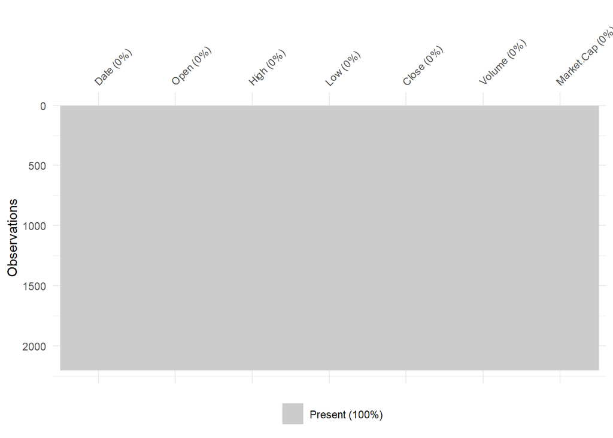

```r
#Heat map to check any missing data
vis_miss(train_data)
```

- The data is clean. There are no missing element. There is nothing unusual about the data.

##### We plot the initial bitcoin close price for each day from Apr 2013 to May 2019.

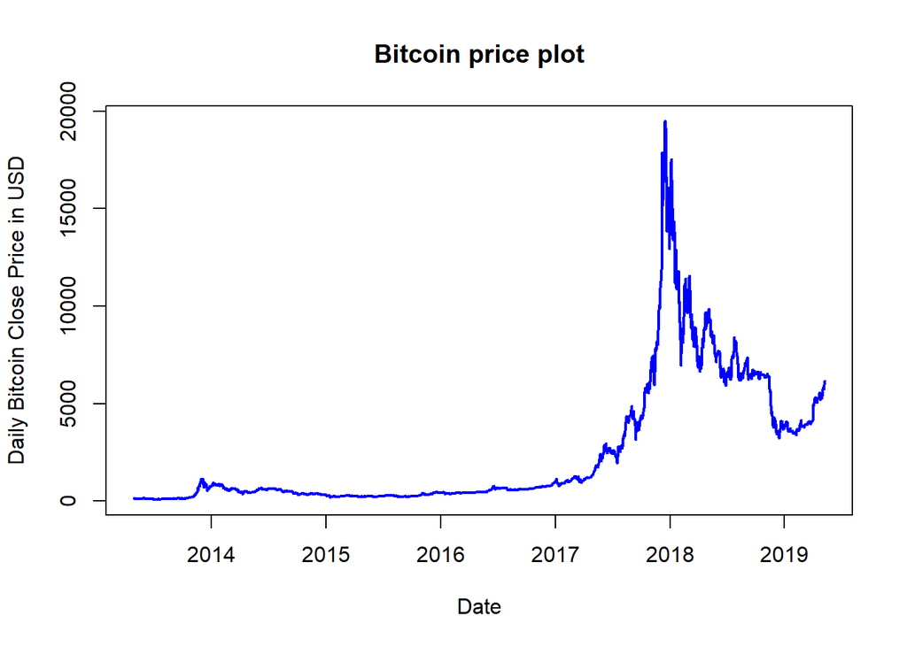

```r
plot(train_data$Close~train_data$Date,xlab='Date',ylab ='Daily Bitcoin Close Price in USD',
     main='Bitcoin price plot', type='l',lwd=2,col='blue')
```

### We proceed with next steps to make the data stationary to apply time series models -

- astsa package is used for applied stastical time series models
- Creating timeseries data using ts()

```r
library(astsa)

bit_train<-ts(train_data$Close)
bit_test<-ts(test_data$Close)
```

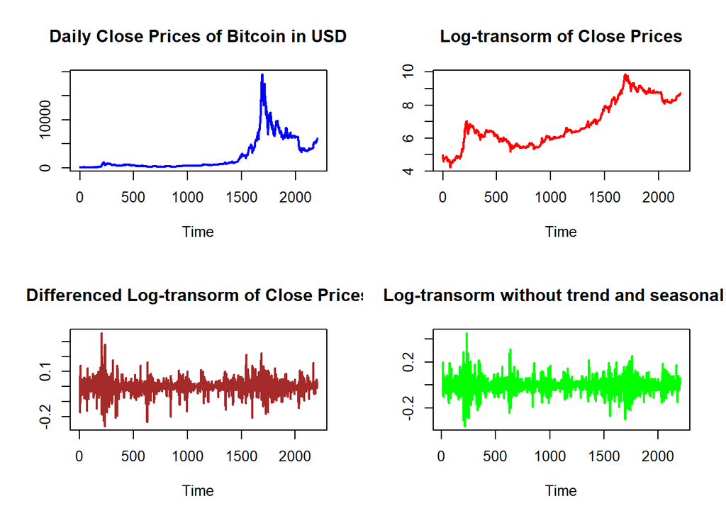

```r
par(mfrow=c(2,2))

plot(bit_train, main='Daily Close Prices of Bitcoin in USD', ylab='', col='blue', lwd=2)
plot(log(bit_train), main='Log-transorm of Close Prices', ylab='', col='red', lwd=2)
plot(diff(log(bit_train)), main='Differenced Log-transorm of Close Prices', ylab='', col='brown', lwd=2)
plot(diff(diff(log(bit_train)),12), main='Log-transorm without trend and seasonaliy', ylab='', col='green', lwd=2)
```

- We notice that our data is non-stationary, we apply log-return method to make it stationary.
- Log return is achieved by diff(log())
- We plot 4 graphs in efforts to see if log-return methods makes the data stationary before we apply AR or MA or ARMA or ARIMA models.

##### Performing Ljung-Box test for correlation

```r
Box.test(diff(log(bit_train)), lag = log(length(diff(log(bit_train)))),type ='Ljung-Box')
```

```
##
##  Box-Ljung test
##
## data:  diff(log(bit_train))
## X-squared = 19.262, df = 7.6971, p-value = 0.01135
```

- We can notice that p < 0.05, there exists some correlation with the close price of the bitcoin

##### We perform dickey-fuller test to determine stationary in the data

```r
adf.test(diff(log(bit_train)), alternative="stationary", k=0)
```

```
##
##  Augmented Dickey-Fuller Test
##
## data:  diff(log(bit_train))
## Dickey-Fuller = -46.741, Lag order = 0, p-value = 0.01
## alternative hypothesis: stationary
```

##### Auto Correlation Function (ACF) and Partial Auto Correlation Function (PACF) of the differenced data is observed to get the p,d,q values.

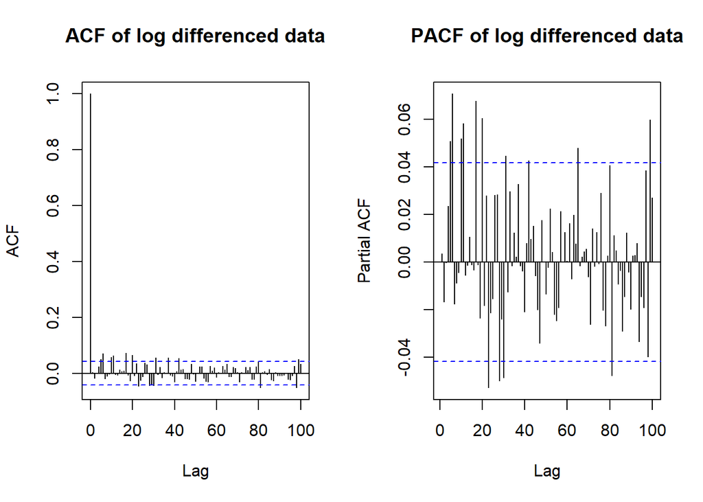

```r
par(mfrow=c(1,2))
acf(diff(log(bit_train)), main='ACF of log differenced data', 100)
pacf(diff(log(bit_train)), main='PACF of log differenced data', 100)
```

##### We fit arima(4,1,3) model with seasonal component included in it, below plot shows the predictions

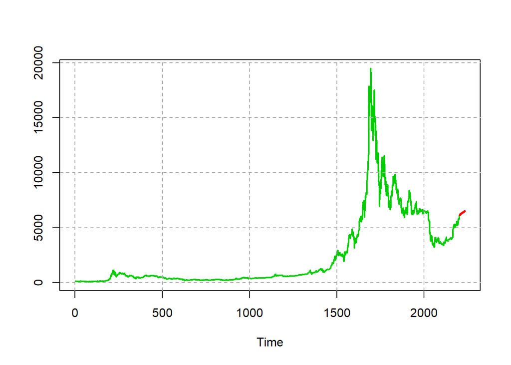

```r
fit <- arima(log(bit_train), c(4, 1, 3),seasonal = list(order = c(1, 1, 1), period = 3))
pred <- predict(fit, n.ahead = 10*3)
ts.plot(bit_train,2.718^pred$pred, lty = c(1,5),col=c(3,2),lwd=c(2,3))
grid(nx = NULL, ny = NULL, col = "darkgray", lty = 2,lwd = par("lwd"), equilogs = TRUE)
```

### We now proceed with Exponential Smoothing Methods

##### 1. Simple Exponential Smoothing

##### 2. Holt’s Linear Trend Method

##### 3. Damped Holt’s Method

- We have reduced the window size for the time series to start from observation number= 2000 for graph plotting purposes.

##### We notice that AIC is 3122 and MAPE=2.009 for Simple Exponential Smoothing

```r
close_ses <- ses(window(bit_train,start=2000),h=5)
summary(close_ses)
```

```
##
## Forecast method: Simple exponential smoothing
##
## Model Information:
## Simple exponential smoothing
##
## Call:
##  ses(y = window(bit_train, start = 2000), h = 5)
##
##   Smoothing parameters:
##     alpha = 0.9948
##
##   Initial states:
##     l = 6476.3853
##
##   sigma:  146.2404
##
##      AIC     AICc      BIC
## 3122.869 3122.989 3132.824
##
## Error measures:
##                    ME     RMSE      MAE         MPE     MAPE      MASE
## Training set -1.49238 145.5218 86.47161 -0.07900579 2.009397 0.9946959
##                      ACF1
## Training set -0.000699998
##
## Forecasts:
##      Point Forecast    Lo 80    Hi 80    Lo 95    Hi 95
## 2204       6173.525 5986.111 6360.940 5886.900 6460.151
## 2205       6173.525 5909.170 6437.881 5769.229 6577.822
## 2206       6173.525 5850.040 6497.011 5678.797 6668.254
## 2207       6173.525 5800.159 6546.892 5602.511 6744.540
## 2208       6173.525 5756.199 6590.852 5535.279 6811.772
```

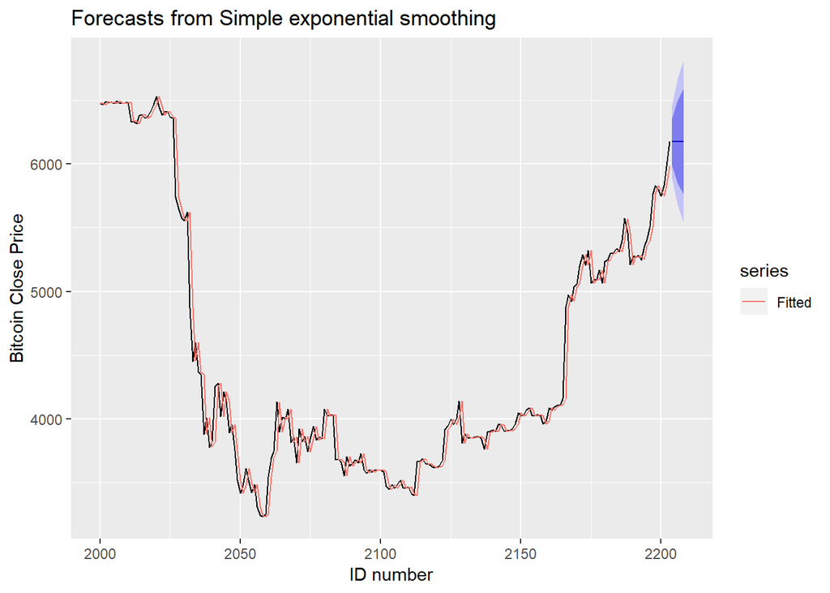

```r
autoplot(close_ses) +
  autolayer(fitted(close_ses), series="Fitted") +
  ylab("Bitcoin Close Price") + xlab("ID number")
```

##### We notice that AIC is 3123 and MAPE=2.024 for Holt’s method

```r
close_holt<-holt(window(bit_train,start=2000),h=5)

summary(close_holt)
```

```
##
## Forecast method: Holt's method
##
## Model Information:
## Holt's method
##
## Call:
##  holt(y = window(bit_train, start = 2000), h = 5)
##
##   Smoothing parameters:
##     alpha = 0.95
##     beta  = 0.0302
##
##   Initial states:
##     l = 6596.5756
##     b = -30.0643
##
##   sigma:  145.8238
##
##      AIC     AICc      BIC
## 3123.676 3123.979 3140.266
##
## Error measures:
##                    ME     RMSE      MAE       MPE     MAPE     MASE
## Training set 11.07994 144.3871 87.51121 0.2582899 2.024862 1.006655
##                      ACF1
## Training set -0.006579805
##
## Forecasts:
##      Point Forecast    Lo 80    Hi 80    Lo 95    Hi 95
## 2204       6204.507 6017.626 6391.388 5918.697 6490.316
## 2205       6242.734 5981.041 6504.426 5842.510 6642.958
## 2206       6280.961 5958.250 6603.672 5787.417 6774.504
## 2207       6319.188 5942.405 6695.971 5742.947 6895.428
## 2208       6357.415 5930.780 6784.050 5704.933 7009.897
```

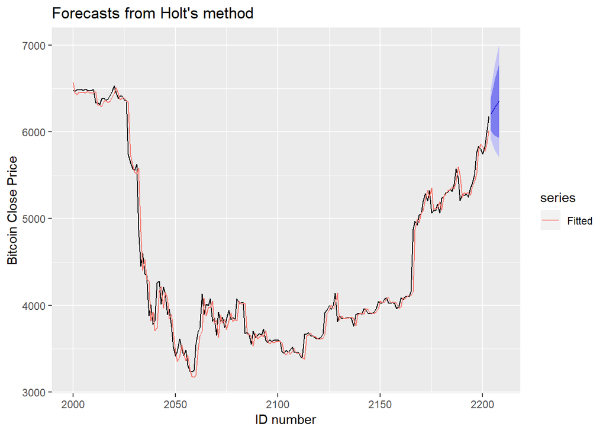

```r
autoplot(close_holt) +
  autolayer(fitted(close_holt), series="Fitted") +
  ylab("Bitcoin Close Price") + xlab("ID number")
```

##### We notice that AIC is 3121 and MAPE=1.9867 for Damped Holt’s method. This has the lowest MAPE as compared to above methods.

```r
close_holt_damp<-holt(window(bit_train,start=2000),h=5,damped = TRUE,phi=0.9)

summary(close_holt_damp)
```

```
##
## Forecast method: Damped Holt's method
##
## Model Information:
## Damped Holt's method
##
## Call:
##  holt(y = window(bit_train, start = 2000), h = 5, damped = TRUE,
##
##  Call:
##      phi = 0.9)
##
##   Smoothing parameters:
##     alpha = 0.8922
##     beta  = 0.0863
##     phi   = 0.9
##
##   Initial states:
##     l = 6487.7257
##     b = 0.0417
##
##   sigma:  145.5593
##
##      AIC     AICc      BIC
## 3121.912 3122.215 3138.503
##
## Error measures:
##                     ME     RMSE      MAE         MPE     MAPE      MASE
## Training set 0.1905004 143.7644 85.50589 -0.01884714 1.986799 0.9835871
##                     ACF1
## Training set 0.002719271
##
## Forecasts:
##      Point Forecast    Lo 80    Hi 80    Lo 95    Hi 95
## 2204       6195.081 6008.539 6381.623 5909.790 6480.372
## 2205       6230.869 5971.000 6490.738 5833.434 6628.304
## 2206       6263.078 5938.803 6587.354 5767.141 6759.015
## 2207       6292.067 5908.050 6676.083 5704.765 6879.369
## 2208       6318.156 5877.430 6758.882 5644.124 6992.188
```

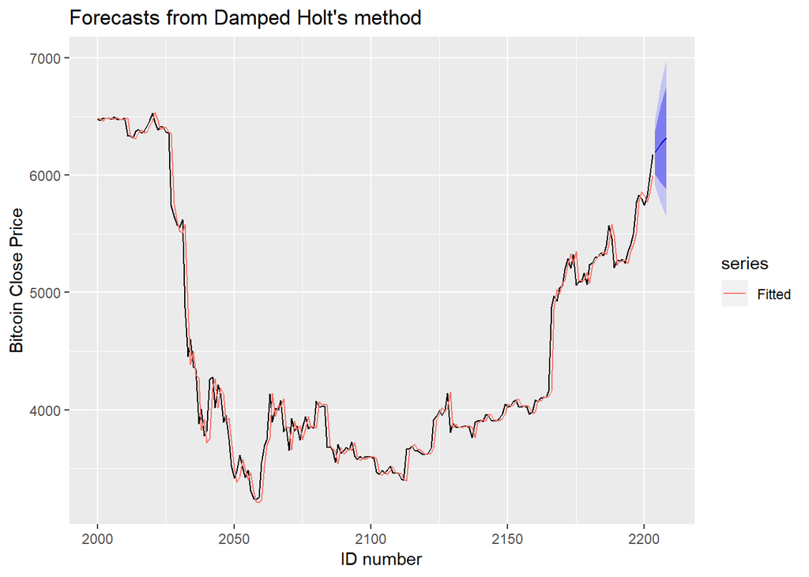

```r
autoplot(close_holt_damp) +
  autolayer(fitted(close_holt_damp), series="Fitted") +
  ylab("Bitcoin Close Price") + xlab("ID number")
```

##### Plotting in Holt’s linear method forecasts and Damped Holt’s method forecasts in single graph.

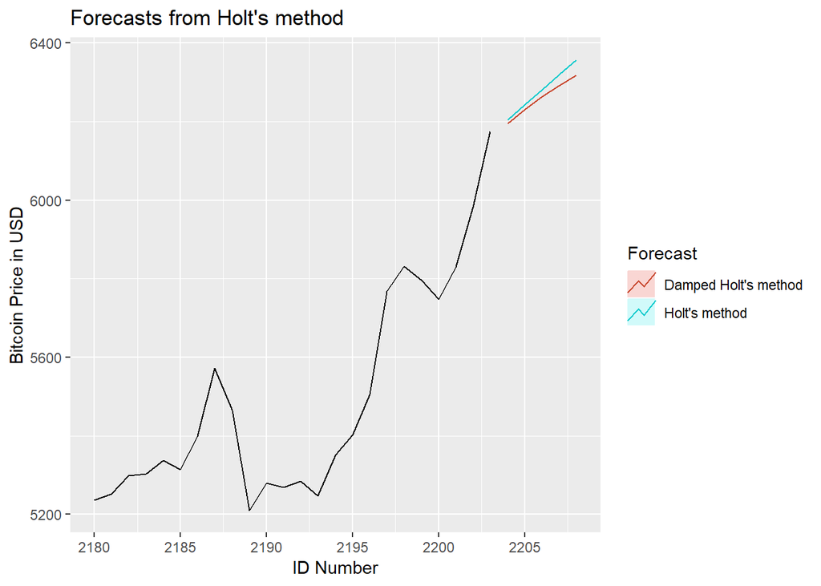

```r
autoplot(window(bit_train,start=2180)) +
  autolayer(close_holt, series="Holt's method", PI=FALSE) +
  autolayer(close_holt_damp, series="Damped Holt's method", PI=FALSE) +
  ggtitle("Forecasts from Holt's method") + xlab("ID Number") +
  ylab("Bitcoin Price in USD") +
  guides(colour=guide_legend(title="Forecast"))
```

### We now proceed to next stage: determing the model parameters using ets() E= Error, T=Trend, S=Seasonal

```r
bit_train_2000 <- window(bit_train, start=2000)
model_param <- ets(bit_train_2000,model="ZZZ",damped = TRUE)
summary(model_param)
```

```
## ETS(A,Ad,N)
##
## Call:
##  ets(y = bit_train_2000, model = "ZZZ", damped = TRUE)
##
##   Smoothing parameters:
##     alpha = 0.8953
##     beta  = 0.0825
##     phi   = 0.9073
##
##   Initial states:
##     l = 6529.5518
##     b = 0.2486
##
##   sigma:  145.6052
##
##      AIC     AICc      BIC
## 3124.041 3124.467 3143.950
##
## Training set error measures:
##                     ME     RMSE     MAE         MPE     MAPE      MASE
## Training set 0.1399551 143.8098 85.7281 -0.01817569 1.990344 0.9861432
##                     ACF1
## Training set 0.002625989
```

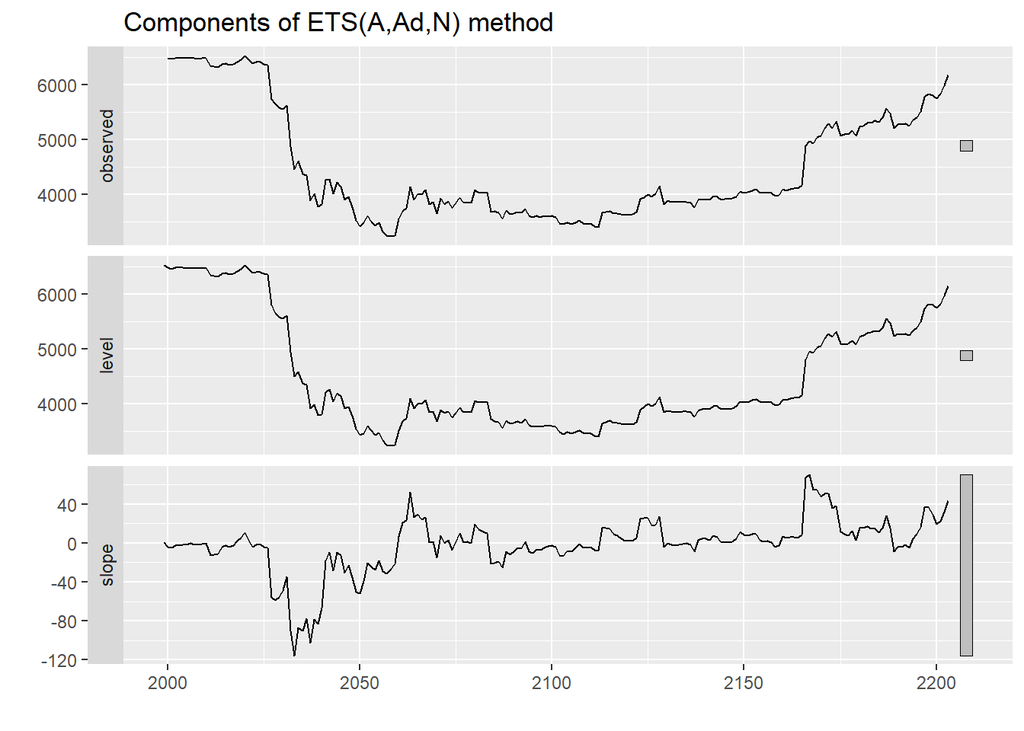

```r
autoplot(model_param)
```

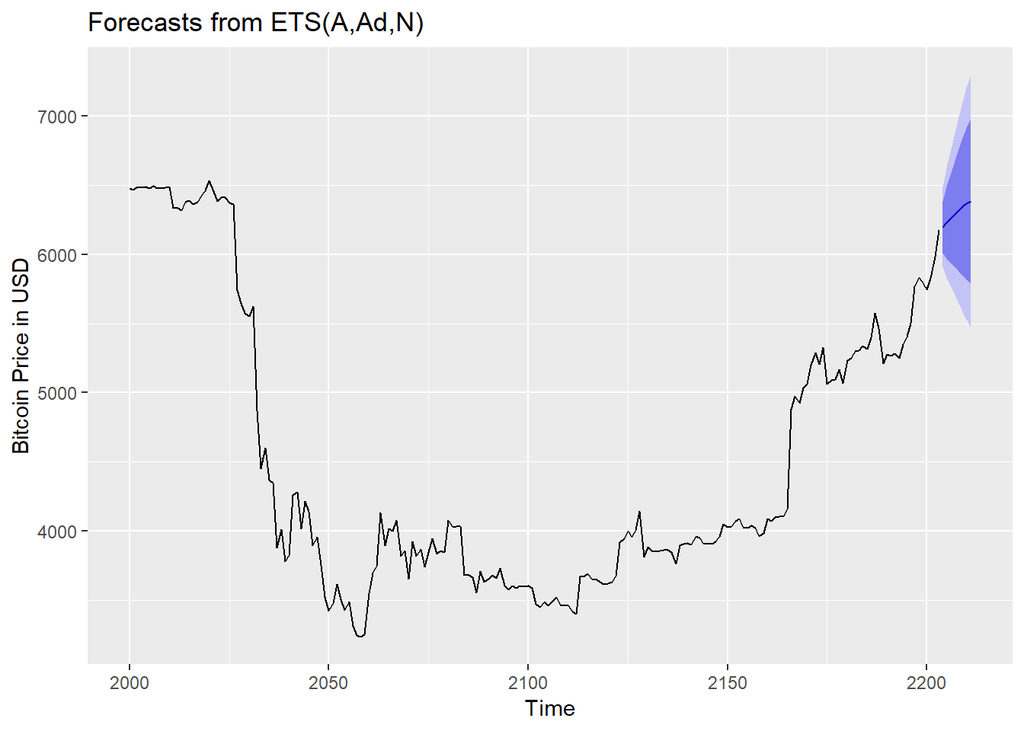

```r
model_param %>% forecast(h=8) %>%
  autoplot() +
  ylab("Bitcoin Price in USD")
```